# Bayesian Non-Linear Mixed-Effects Model of Argatroban

# 1 Introduction

```r
library(ggplot2)
library(rstan)
library(nlme)
library(forestplot)
library(kableExtra)
library(reshape2)
library(dplyr)
rstan_options(auto_write = TRUE)
options(mc.cores = parallel::detectCores() )
```

# 2 Disclaimer

This demo presents a Bayesian version of the Argatroban ODE study presented in [#fitzmaurice2008longitudinal](https://www.routledge.com/Longitudinal-Data-Analysis/Fitzmaurice-Davidian-Verbeke-Molenberghs/p/book/9781584886587).

The Bayesian parameter estimates are compared to the `nlme` and `SAS` estimates following the R scripts available [here](https://www4.stat.ncsu.edu/~davidian/st732/examples.html)

# 3 Introduction

The pharmaceutical drug Argatroban is an anticoagulant that was approved for commercial use by the Food and Drug Administration (FDA) in 2000. This drug is indicated for the treatment and prophylaxis of thrombosis in patients with heparin-induced thrombocytopeniaThrombocytopenia is defined as the deficiency of platelets in the blood. One of the main consequences is slow blood clotting after receiving an injury., and in patients with other conditions [#Dhillon2009].

In this particular dataset, it is mentioned in [#fitzmaurice2008longitudinal] that there were nine different doses of Argatroban ranging from 1.0 to 5.0 g/kg/min in increments of 0.5, and four subjects were assigned at random to each dose. A final subject received a dose of 4.38 g/kg/min for a total of 37 different subjects. Different blood samples were acquired from the subjects, from where it was able to estimate the current Argatroban concentration present plasma.

# 4 Exploratory Data Analysis

```r
data = read.table("https://www4.stat.ncsu.edu/~davidian/st732/examples/argconc.dat")
colnames(data) = c('obsno','indiv','dose','time','conc')

head(data)
```

```
##   obsno indiv dose time  conc
## 1     1     1    1   30  95.7
## 2     2     1    1   60 122.0
## 3     3     1    1   90 133.0
## 4     4     1    1  160 162.0
## 5     5     1    1  200 200.0
## 6     6     1    1  240 172.0
```

```r
means_by_conc = data %>%
        group_by(time, dose) %>%
        summarise(conc = mean(conc))
means_by_conc$dose = as.factor(means_by_conc$dose)
summary(means_by_conc)
```

```
##       time            dose         conc
##  Min.   : 30.0   1.5    :14   Min.   :  43.0
##  1st Qu.:115.0   2      :14   1st Qu.: 224.6
##  Median :240.0   2.5    :14   Median : 461.4
##  Mean   :204.1   3      :14   Mean   : 505.2
##  3rd Qu.:275.0   3.5    :14   3rd Qu.: 758.6
##  Max.   :360.0   4      :14   Max.   :1558.0
##                  (Other):53
```

```r
data_plot = data
data_plot$indiv = as.factor(data_plot$indiv)
data_plot$dose = as.factor(data_plot$dose)
```

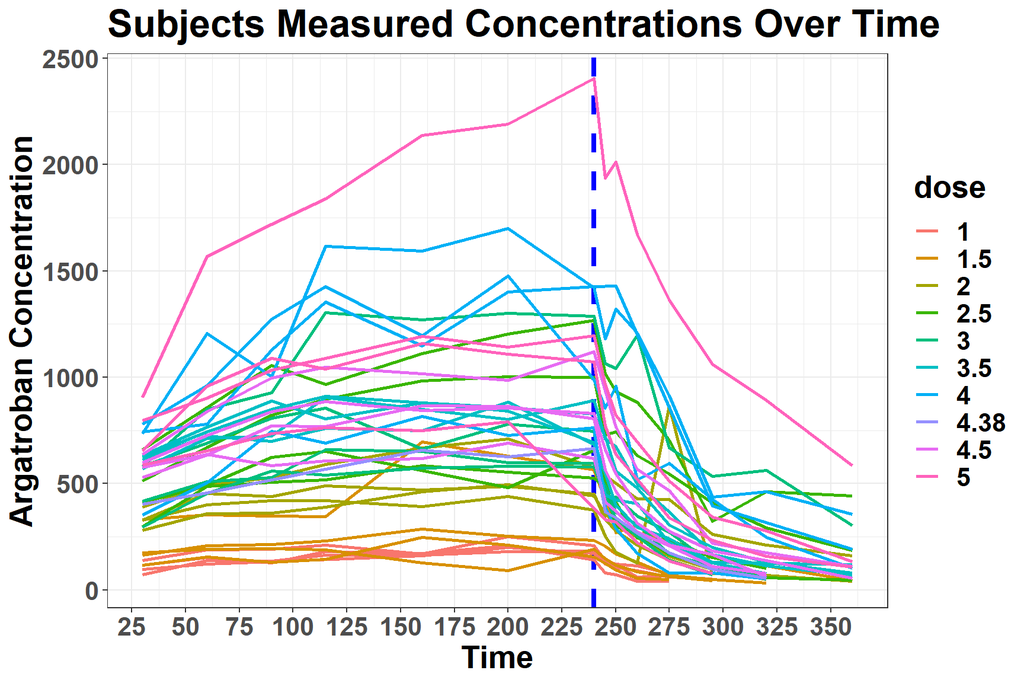

```r
ggplot(data=data_plot, aes(x=time, y=conc, group=indiv, colour=dose))+
  geom_vline(xintercept=240, colour="blue", size=1.5, linetype='dashed') +
  geom_line(size=1)+
  scale_x_continuous(breaks=seq(0, 360, by = 25))+
  theme_bw() +
  xlab('Time') +
  ylab('Argatroban Concentration') +
  ggtitle('Subjects Measured Concentrations Over Time')+
   theme(text = element_text(size=20, face='bold'))
```

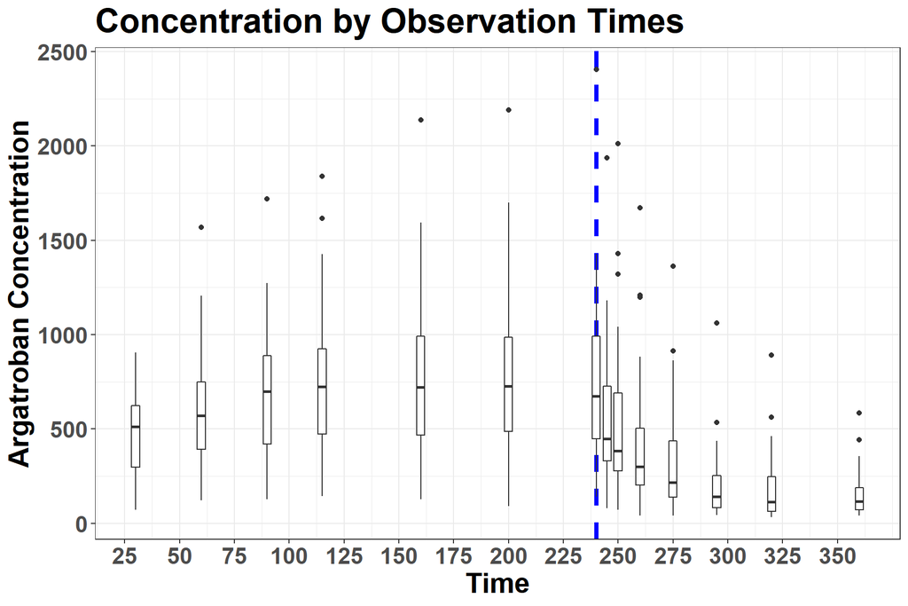

```r
ggplot(data_plot, aes(x=time, y=conc, group=time)) +
  geom_vline(xintercept=240, colour="blue", size=1.5, linetype='dashed') +
  geom_boxplot()  +
  scale_x_continuous(breaks=seq(0, 360, by = 25))+
  theme_bw() +
  xlab('Time') +
  ylab('Argatroban Concentration') +
  ggtitle('Concentration by Observation Times')+
   theme(text = element_text(size=20, face='bold'))
```

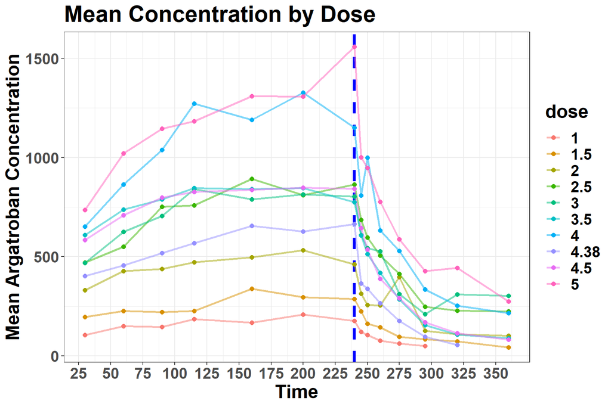

```r
ggplot(means_by_conc, aes(x=time, y=conc, group=dose, colour=dose)) +
  geom_vline(xintercept=240, colour="blue", size=1.5, linetype='dashed') +
  geom_line(size=1, alpha=0.5)+
  geom_point(size=2)+
  scale_x_continuous(breaks=seq(0, 360, by = 25))+
  theme_bw() +
  xlab('Time') +
  ylab('Mean Argatroban Concentration') +
  ggtitle('Mean Concentration by Dose')+
   theme(text = element_text(size=20, face='bold'))
```

We observe the measured Argatroban concentration for all the subjects and how as the infusion dose of the drug increases, the concentration on plasma tends to increase accordingly. However, after the 4 hours of continuous administration, there is a sudden drop in the blood concentration of Argatroban caused by the metabolization of the drug. Each patient has different response curves even under the same dose administered. We notice at time t_{inf}=240 the exponential decay dynamics after the administration of the drug stopped.

# 5 ODE model

The data shows a non-linear response that has a major change when the subjects stop receiving the drug. A proposed model for the drug concentration is the one-compartment where we assume that the amount of drug in the body $A(t)$,constant infusing supply $D$, and first order clearance rate per volume as $k_{e}$

$\frac{dA}{dt}=D-k_{e}A(t)$,

where the initial condition is $A(0)=0$ since no patient was receiving a drug before the beginning of the experiment. The analytical solution for this equation is given by

$A(t)=\frac{D}{k_{e}}\left(1-e^{k_{e}t}\right)$.

This model can be rewritten by expressing the amount of drug $A(t)$ in terms of the blood plasma drug concentration, $C(t)=A(t)/V$, and decompose the rate $k_{e}=Cl/V$ as the clearance rate per volume of the compartment. In this case, the ODE now takes the form of

$C(t)=\frac{D}{Cl}\left(1-e^{\frac{Cl}{V}t}\right)$.

The last step in the ODE model derivation is to consider the end of the drug intake at time $t_{inf}=240$ min. One way to model this is by discounting the analytical solution by a factor $e^{-kt_{inf}}$. This leads to the modified ODE solution

$C(t)=\frac{D}{Cl}\left[exp\left(-\frac{Cl}{V}(t-t_{inf})_{+}\right)-exp\left(-\frac{Cl}{V}t\right)\right]$,

where $(t-t_{inf})_{+}=0$ if $t\leq t_{inf}$ and $(t-t_{inf})_{+}=t-t_{inf}$ if $t>t_{inf}$

# 6 Hierarchical Model

Part of the goal of the Argatroban study was to characterize the typical response of the subjects based on different doses of the drug. Also, to identity the amount of subject-specific variation in the response. With these two objectives in mind, we fit the response function to the patient data, using our hierarchical model which can be written as a multi-stage model:

*Stage-1: individual level*

$Y_{ij}= C\left(t_{ij},\mathbf{U}_{i},\vec{\theta}_{i}\right)+e_{ij}$

where $j=1,...,n_{i}$. This formulation implies that first moment of the response variable is $E[Y_{ij}]=C(t_{ij};\mathbf{U}_{i},\vec{\theta}_{i})$, where $\mathbf{U}_{i}=(D_{i},t_{inf}=240)^{t}$ represents the dose of Argatroban infused to each patient until time $t_{inf}=240$ min when the administration of the drug was stopped.

For the second stage formulation, we express the parameters of the non-linear response in terms of population level parameters $\vec{\beta}=\left(\beta_{1},\beta_{2}\right)^{t}$, and allow for subject-specific contributions in the form of constant random effects $\mathbf{b}_{i}$. We assume that $\mathbf{b}_{i}\sim N(\mathbf{0},G)$ with $G$ the covariance matrix of random effects. With these considerations the second stage model is represented as

*Stage-2 Population level*

$\vec{\theta}_{i}= \mathbf{d}\left(\vec{A}_{i},\vec{\beta},\mathbf{b}_{i}\right),$

where $i=1,...,N$ and the subject-specific parameters vector is written as $vec{\theta}_{i}=(Cl^{*},V^{*})^{t}$. Note that the ODE parameters $Cl$ and $V$ need to be strictly non-negative (or zero), thus we use an alternative formulation of the population level parameters as

$Cl^{*}=log(Cl)=\beta_{1}+b_{i1}$

and

$V^{*}=log(V)= \beta_{2}+b_{i2}$.

Under this model, $e^{\beta_{1}}$ and $e^{\beta_{2}}$ will represent the medians of the clearance and volume parameters in the population and $b_{i1}$ and $b_{i2}$ represent the random effects of the populations.

*Conditional mean and conditional covariance matrix*

*The conditional mean response for the $i$th individual*

$E\left(Y_{ij}|\mathbf{U}_{i},\vec{\theta}_{i}\right)=\frac{D_{i}}{e^{Cl_{i}^{*}}}\left[exp\left(-\frac{e^{Cl_{i}^{*}}}{e^{V_{i}^{*}}}(t_{ij}-t_{inf})_{+}\right)-exp\left(-\frac{e^{Cl_{i}^{*}}}{e^{V_{i}^{*}}}t_{ij}\right)\right]$

and the intra-individual covariance structure is

$Var\left(Y_{i}|\mathbf{U}_{i},\vec{\theta}_{i}\right)=\sigma_{e}^{2}diag\left\{ C^{2\lambda}(t_{i1},\mathbf{U}_{i},\mathbf{\vec{\theta}}_{i}),...,C^{2\lambda}(t_{in_{i}},\mathbf{U}_{i},\vec{\theta}_{i})\right\}$.

As noted in [#fitzmaurice2008longitudinal], this covariance structure is known as the “power variance” and assumes that the records are sufficiently spaced so that the autocorrelation of the realization process is considered negligible. When we take the power of the concentration of the drug at different times $t_{i1},...,t_{in_{i}}$, we assume that the measurement error is proportional to “an unknown power-of-mean response”. This is an standard way to represent that the assays used the drug concentration in blood plasma, would provide non-constant measurement errors for which their variance increases with the magnitude of the response. We define in the vector $\vec{\alpha}=(\sigma_{e}^{2},\lambda)$ the elements of the intra-individual covariance components.

*Stage 3- Hyperpriors:*

In the last specification of the hierarchical model, we define the hyperpriors

$\left(\vec{\beta},\vec{\alpha},G\right)\sim f\left(\vec{\beta},\vec{\alpha},G\right)=f(\vec{\beta})f(\vec{\alpha})f(G).$

*Pop-level parameters (main effects)* In our analysis, we consider weakly informative priors for the joint vector of population-level parameters $\vec{\beta}$. Our choice is to consider a bivariate normal distribution

$\vec{\beta}\sim N_{2}(\mathbf{0},\sigma^{2}\otimes\mathbf{I}_{2\times2})$,

which is centered at zero, and with variance parameter $\sigma^{2}=10^{2}$. Note that this approach is similar to the case of priors chosen for the parameters used in Bayesian linear regression. For the elements of $\vec{\alpha}$ we define,

$\lambda\sim LogNormal(0, 1)$ and $\sigma_{e}\sim TruncCauchy(0,\:2.5)$

since the STAN documentation mentions that the truncated Cauchy distribution leads to good results for scale parameters under Hamiltonian Monte Carlo [#RStan2016].

*Subject-Specific parameters (random effects)*

$\mathbf{b}_{i} \sim N_{2}(\mathbf{0},G)$

For the covariance matrix of random effects G, instead of using an inverse-Wishart distribution, we decompose G to make explicit its associated correlation matrix with

*Covariance and correlation matrix of random effects*

$G=diag(\sigma_{1}^{2},\sigma_{2}^{2})\,\Omega\,diag(\sigma_{1}^{2},\sigma_{2}^{2})$

where is the correlation matrix between the random effects $b_{i1}$ and $b_{i2}$, and $diag(\sigma_{1}^{2},\sigma_{2}^{2})$ represents a diagonal matrix with diagonal entries the variance of the random effects. Under this decomposition, we can place an LKJ prior distribution in the correlation matrix as

$\Omega\sim LKJ(\eta)$

which reflects a low a priori correlation between the random effects and a weakly informative prior in their scale parameter. In the following section, we show the results of this set up by doing full Bayesian inference.

# 7 Model fitting

## 7.1 nlme library

Example taken from the [course notes] (https://www4.stat.ncsu.edu/~davidian/st732/examples/arg_nlme.R)

```r
ode_model = function(t, b1, b2, dose){
    tinf = 240
    cl = exp(b1)
    v = exp(b2)
  t1 = t <= tinf
  t2 = tinf*(1 - t1) + t1*t
  f1 = (dose/cl) * (1 - exp(-cl*t2/v)) * exp(-cl*(1 - t1)*(t - tinf)/v)

  return(f1)
}


nlme_fit = nlme(conc ~ ode_model(time, b1, b2, dose),
                data = data,
                fixed = list(b1 ~ 1, b2 ~1),
                random = list(b1 ~ 1, b2 ~ 1),
                groups = ~ indiv,
                weights = varPower(0.5),
                start = list(fixed = c(-6.0,-2.0)),
                method = "ML",
                verbose = FALSE)


print(summary(nlme_fit))
```

```
## Nonlinear mixed-effects model fit by maximum likelihood
##   Model: conc ~ ode_model(time, b1, b2, dose)
##  Data: data
##        AIC      BIC    logLik
##   5738.425 5767.568 -2862.212
##
## Random effects:
##  Formula: list(b1 ~ 1, b2 ~ 1)
##  Level: indiv
##  Structure: General positive-definite, Log-Cholesky parametrization
##          StdDev      Corr
## b1        0.37168388 b1
## b2        0.06753306 0.268
## Residual 20.41961354
##
## Variance function:
##  Structure: Power of variance covariate
##  Formula: ~fitted(.)
##  Parameter estimates:
##     power
## 0.2432883
## Fixed effects: list(b1 ~ 1, b2 ~ 1)
##        Value  Std.Error  DF   t-value p-value
## b1 -5.432545 0.06230331 437 -87.19513       0
## b2 -1.917953 0.02513017 437 -76.32073       0
##  Correlation:
##    b1
## b2 0.156
##
## Standardized Within-Group Residuals:
##         Min          Q1         Med          Q3         Max
## -2.48366063 -0.42424580  0.03283586  0.57935560  9.38411161
##
## Number of Observations: 475
## Number of Groups: 37
```

```r
nlme_fit$sigma
```

```
## [1] 20.41961
```

```r
nlme_fit$coef$random
```

```
## $indiv
##              b1           b2
## 1   0.264321671  0.018991539
## 2   0.105589915  0.003912753
## 3   0.356888629  0.012955220
## 4   0.251467972  0.020897030
## 5   0.283323599  0.021841624
## 6   0.598379353  0.031227548
## 7  -0.382613188 -0.033197543
## 8   0.553777074  0.033120545
## 9  -0.037056877  0.051994675
## 10  0.032167632  0.007832001
## 11 -0.436299657  0.012158967
## 12  0.002540403 -0.018077430
## 13 -0.552154111 -0.030333714
```

[output cut: 24 more lines]

```r
VarCorr(nlme_fit)
```

```
## indiv = pdLogChol(list(b1 ~ 1,b2 ~ 1))
##          Variance     StdDev      Corr
## b1       1.381489e-01  0.37168388 b1
## b2       4.560715e-03  0.06753306 0.268
## Residual 4.169606e+02 20.41961354
```

```r
D.T = diag(VarCorr(nlme_fit)[1:2,2])
D.T
```

```
##           [,1]       [,2]
## [1,] 0.3716839 0.00000000
## [2,] 0.0000000 0.06753306
```

```r
D.corr = as.numeric(VarCorr(nlme_fit)[2,3])
D.corr
```

```
## [1] 0.268
```

```r
D.Gam = diag(2)
D.Gam[1,2]=D.corr; D.Gam[2,1]=D.corr
D.Gam
```

```
##       [,1]  [,2]
## [1,] 1.000 0.268
## [2,] 0.268 1.000
```

```r
D.nlme_fit = D.T%*%D.Gam%*%D.T
D.nlme_fit
```

```
##             [,1]        [,2]
## [1,] 0.138148907 0.006727055
## [2,] 0.006727055 0.004560714
```

```r
nlme_fit_summary = summary(nlme_fit)



G_RESCALE_FACTOR = 1000
nlme_estimates = data.frame(beta1=as.numeric(nlme_fit$coefficients$fixed[1]),
                            beta2=as.numeric(nlme_fit$coefficients$fixed[2]),
                            corr = nlme_fit_summary$corFixed[1, 2],
                            sigmae=nlme_fit$sigma,
                            lambda=as.numeric(nlme_fit$modelStruct$varStruct),
                            G11=D.nlme_fit[1,1],
                            G12=D.nlme_fit[1,2]*G_RESCALE_FACTOR,
                            G22=D.nlme_fit[2,2]*G_RESCALE_FACTOR)
nlme_estimates$cv_cl = sqrt(nlme_estimates$G11)*100
nlme_estimates$cv_v = sqrt(nlme_estimates$G22/G_RESCALE_FACTOR)*100

nlme_estimates_se = data.frame(beta1=sqrt(nlme_fit$varFix)[1, 1],
                              beta2=sqrt(nlme_fit$varFix)[2, 2],
                              corr=NA, sigmae=NA, lambda=NA, G11=NA, G12=NA,
                              G22=NA, cv_cl=NA, cv_v=NA)

nlme_estimates = t(round(nlme_estimates, 2))
nlme_estimates_se = lapply(nlme_estimates_se, round, 3)



sas_estimates = data.frame(beta1=-5.424, beta2=-1.924, corr=0.19, sigmae=13.88,
                           lambda=NA, G11=0.141, G12=6.56, G22=6.01,
                           cv_cl=37.54, cv_v=7.75)
sas_estimates_se = data.frame(beta1=0.063, beta2=0.030,
                              corr=NA, sigmae=NA, lambda=NA, G11=NA, G12=NA,
                              G22=NA, cv_cl=NA, cv_v=NA)

sas_estimates = t(sas_estimates)
sas_estimates_se = lapply(sas_estimates_se, round, 3)

freq_estimates = cbind(nlme_estimates, nlme_estimates_se,
                       sas_estimates, sas_estimates_se)
colnames(freq_estimates) = c('Estimate', 'S.E.', 'Estimate', 'S.E.')
freq_estimates
```

```
##        Estimate S.E.  Estimate S.E.
## beta1  -5.43    0.062 -5.424   0.063
## beta2  -1.92    0.025 -1.924   0.03
## corr   0.16     NA    0.19     NA
## sigmae 20.42    NA    13.88    NA
## lambda 0.24     NA    NA       NA
## G11    0.14     NA    0.141    NA
## G12    6.73     NA    6.56     NA
## G22    4.56     NA    6.01     NA
## cv_cl  37.17    NA    37.54    NA
## cv_v   6.75     NA    7.75     NA
```

## 7.2 STAN

```r
cat(readLines('argatroban_model.stan'), sep='\n')
```

```
## functions {
##   vector ode_model(vector times, real logcl, real logv, real dose){
##
##     real tinf;
##     real cl;
##     real v;
##     real t1;
##     real t2;
##     vector[num_elements(times)] f1;
##
##     tinf = 240.0;
##     cl = exp(logcl);
##     v = exp(logv);
##     for (time_ix in 1:num_elements(times)){
##       if (times[time_ix] <= tinf)  {t1=1;}  else {t1=0;}
##       t2 = tinf * (1 - t1) + t1*times[time_ix];
##       f1[time_ix] = (dose/cl) * (1 - exp(-cl*t2/v)) * exp(-cl*(1 - t1)*(times[time_ix] - tinf)/v);
##     }
##     return(f1);
##   }
## }
##
## data{
##   int N_subj;              //Number of subjects
##   int Tot_obs;             // total of observations
##   int N_rec_psubj[N_subj]; // Number of records per subject
##   int N_rand_eff;          // Number of random effects
##   int p;                   // number of population level parameters of \beta vector
##
##   int indiv[Tot_obs];      //vector indiv ID for all subjects
##   real dose[Tot_obs];      //vector dose records all subjects
##   vector[Tot_obs] obs_times;    //vector times of records all subjects
##
##   real conc[Tot_obs];      //vector concentration records all subjects
##
##   //// Paramters of priors
##   // shape parameter lkj_corr_cholesky
##   real eta_ljk_shape;
##   // Population parameters prior
##   real beta_loc;
```

[output cut: 88 more lines]

```
##   //Median clearance and volume params for all the patients
##   median_cl = exp(logcl)*1000;
##   median_v = exp(logv)*1000;
##
##   // coefficient of variation of clearance and volume for all patients
##   cv_cl = sqrt(G[1,1])*100;
##   cv_v  = sqrt(G[2,2])*100;
##
##   for (obs_ix in 1:Tot_obs){
##     conc_check[obs_ix] = normal_rng(m_ij[obs_ix], Sigma_Y_ij[obs_ix]);
##     conc_check_mean[obs_ix] = m_ij[obs_ix];
##   }
##
## }
##
```

```r
stan_data = list(N_subj = length(unique(data$indiv)),
                 Tot_obs = dim(data)[1],
                 N_rec_psubj = as.numeric(table(data$indiv)),
                 N_rand_eff = 2,
                 p = 2,
                 obsno = data$obsno,
                 indiv = data$indiv,
                 dose = data$dose,
                 time = data$time,
                 conc = data$conc,
                 eta_ljk_shape = 3.0,
                 beta_loc = 0, beta_scale = 10,
                 sigma_e_loc = 0, sigma_e_scale = 2.5,
                 lambda_loc = 0, lambda_scale=1
)

load("data/argatroban_stan_inference_simulated.rda")
stan_samples = rstan::extract(argatroban_analytic, permuted=TRUE)
stan_fit = argatroban_analytic

head(stan_samples[['median_cl']])
```

```
##
## iterations     [,1]     [,2]     [,3]     [,4]     [,5]      [,6]     [,7]
##       [1,] 6.203590 4.349646 7.622088 6.048196 6.981525  6.551215 2.805543
##       [2,] 6.045796 5.249650 6.699147 5.833492 7.366821  7.896424 3.139368
##       [3,] 6.856763 4.657972 6.380893 5.750838 5.986678  9.832356 3.165630
##       [4,] 5.708545 5.373297 6.845355 6.777472 5.278652 10.602435 3.295032
##       [5,] 6.571339 5.671792 6.452421 5.915239 7.023909  7.708383 3.120257
##       [6,] 5.410427 5.331593 5.536362 5.741363 6.625743  7.794699 2.949574
##
## iterations     [,8]     [,9]    [,10]    [,11]    [,12]    [,13]    [,14]
##       [1,] 7.075576 3.896285 4.732575 2.835308 4.324490 2.594840 4.766909
##       [2,] 9.198960 3.629603 4.216262 2.786309 4.862135 2.633097 5.052453
##       [3,] 8.812734 3.336722 4.493746 2.639318 4.263756 2.545346 4.443816
##       [4,] 7.369027 3.585987 4.641834 2.902135 4.741934 2.497436 4.326379
##       [5,] 9.557953 3.650478 4.601569 2.956681 4.472254 2.455459 4.717582
```

[output cut: 33 more lines]

```r
stan_params = c("beta", 'G_scales_cor[1,2]', "sigma_e",  "lambda",
                "G[1,1]","G[1,2]", "G[2,2]", 'cv_cl', 'cv_v')
stan_summary = summary(stan_fit, pars= stan_params,
                       prob=c(0.025, 0.5, 0.975))$summary

stan_summary = stan_summary[, c('2.5%', '50%', '97.5%')]
rownames(stan_summary) = c('beta1', 'beta2', 'corr', 'sigmae', 'lambda',
                           'G11', 'G12', 'G22',  'cv_cl', 'cv_v' )

stan_summary[c('G12', 'G22'), ] = (
  stan_summary[c('G12', 'G22'), ]*G_RESCALE_FACTOR
)

stan_summary = round(stan_summary, 3)

fits_summary = cbind(stan_summary, freq_estimates)

stat = colnames(fits_summary)
fits_summary = rbind(stat, fits_summary)

colnames(fits_summary) = c('', 'R-STAN', '', 'R-NLME', '', 'SAS-NLMIXED', '')
rownames(fits_summary) = c('Stat', 'beta_1', 'beta2', 'Corr', 'sigma_e', 'lambda', 'G11', 'G12', 'G22', 'CV Cl', 'CV V')
```

## 7.3 Posterior Predictive

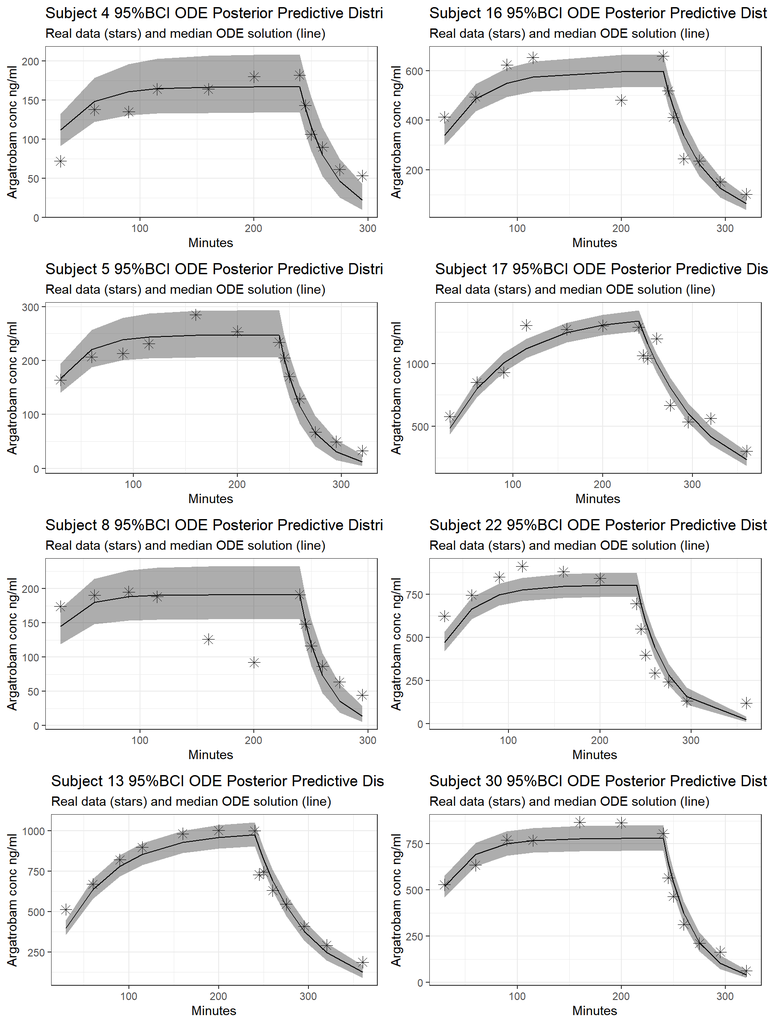

```r
# We use the multiplot function defined in
#http://www.cookbook-r.com/Graphs/Multiple_graphs_on_one_page_(ggplot2)/

multiplot <- function(..., plotlist=NULL, file, cols=1, layout=NULL) {
  library(grid)

  # Make a list from the ... arguments and plotlist
  plots <- c(list(...), plotlist)

  numPlots = length(plots)

  # If layout is NULL, then use 'cols' to determine layout
  if (is.null(layout)) {
    # Make the panel
    # ncol: Number of columns of plots
    # nrow: Number of rows needed, calculated from # of cols
    layout <- matrix(seq(1, cols * ceiling(numPlots/cols)),
                     ncol = cols, nrow = ceiling(numPlots/cols))
  }

  if (numPlots==1) {
    print(plots[[1]])

  } else {
    # Set up the page
    grid.newpage()
    pushViewport(viewport(layout = grid.layout(nrow(layout), ncol(layout))))

    # Make each plot, in the correct location
    for (i in 1:numPlots) {
      # Get the i,j matrix positions of the regions that contain this subplot
      matchidx <- as.data.frame(which(layout == i, arr.ind = TRUE))

      print(plots[[i]], vp = viewport(layout.pos.row = matchidx$row,
                                      layout.pos.col = matchidx$col))
    }
  }
}




post_pred_plot = function(subj_ID, plot_type='pred'){

  range_min = sum(stan_data$N_rec_psubj[1:(subj_ID - 1)]) + 1
  range_max = (sum(stan_data$N_rec_psubj[1:(subj_ID-1)])
                + stan_data$N_rec_psubj[subj_ID])

  subj_rec_range = range_min:range_max

  data_subject = data.frame(stan_data[c("time", "conc")])[subj_rec_range,]


  if (plot_type == 'Checks'){
    summary_y = summ_y_check[subj_rec_range,]
    median_desc = '(points)'
    plot_desc = 'Posterior Predictive Checks'
  } else if (plot_type == 'pred'){
    summary_y = summ_y_predictive[subj_rec_range, ]
    median_desc = 'ODE solution (line)'
    plot_desc = 'ODE Posterior Predictive Distribution'
  }

  df_plot = data.frame(x = data_subject$time,
                          ymin = summary_y$X2.5.,
                          ymedian = summary_y$X50.,
                          ymax = summary_y$X97.5.)


  fig_pred = ggplot()+
    geom_point(data=data_subject, aes(x=time,y=conc),
               colour="black", size=3, shape=8)+
    ggtitle(paste0("Subject ", subj_ID, " 95%BCI ", plot_desc),
            subtitle = paste0("Real data (stars) and median ", median_desc))+
    xlab("Minutes")+ ylab('Argatrobam conc ng/ml') +
    theme_bw()

   if (plot_type == 'Checks'){

    fig_pred = fig_pred +
      geom_errorbar(data=df_plot,
                    aes(x=x, ymin=ymin, ymax=ymax), alpha=1,width=0.2)+
      geom_point(data=df_plot,
                    aes(x=x, y=ymedian),colour="black", size=2)

  } else if (plot_type == 'pred'){
      fig_pred = fig_pred +
        geom_ribbon(data=df_plot,
                   aes(x=x, ymin=ymin, ymax=ymax), alpha=0.4)+
        geom_line(data=df_plot,
                   aes(x=x, y=ymedian), alpha=1)
  }
  return(fig_pred)
}



probs_95BCI = c(0.025, 0.5, 0.975)

summ_y_check = data.frame(summary(stan_fit,
                                  probs=probs_95BCI,
                                  pars="conc_check")$summary)

summ_y_predictive = data.frame(summary(stan_fit,
                                       probs=c(0.025, 0.5, 0.975),
                                       pars="m_ij")$summary)


subj_checks = sort(sample(1:stan_data$N_subj, 8))
multiplot(post_pred_plot(subj_checks[1], plot_type = 'pred'),
          post_pred_plot(subj_checks[2], plot_type = 'pred'),
          post_pred_plot(subj_checks[3], plot_type = 'pred'),
          post_pred_plot(subj_checks[4], plot_type = 'pred'),
          post_pred_plot(subj_checks[5], plot_type = 'pred'),
          post_pred_plot(subj_checks[6], plot_type = 'pred'),
          post_pred_plot(subj_checks[7], plot_type = 'pred'),
          post_pred_plot(subj_checks[8], plot_type = 'pred'), cols=2)
```

## 7.4 Posterior Checks

[figure not shown]

```r
multiplot(post_pred_plot(subj_checks[1], plot_type = 'Checks'),
          post_pred_plot(subj_checks[2], plot_type = 'Checks'),
          post_pred_plot(subj_checks[3], plot_type = 'Checks'),
          post_pred_plot(subj_checks[4], plot_type = 'Checks'),
          post_pred_plot(subj_checks[5], plot_type = 'Checks'),
          post_pred_plot(subj_checks[6], plot_type = 'Checks'),
          post_pred_plot(subj_checks[7], plot_type = 'Checks'),
          post_pred_plot(subj_checks[8], plot_type = 'Checks'), cols=2)
```

## 7.5 Forestplots

Individual-level predictions for ODE parameters

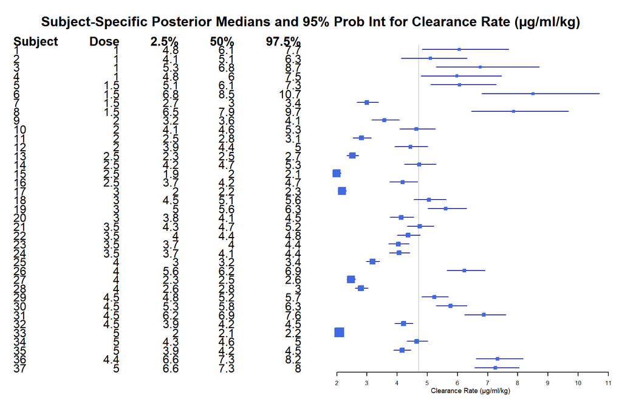

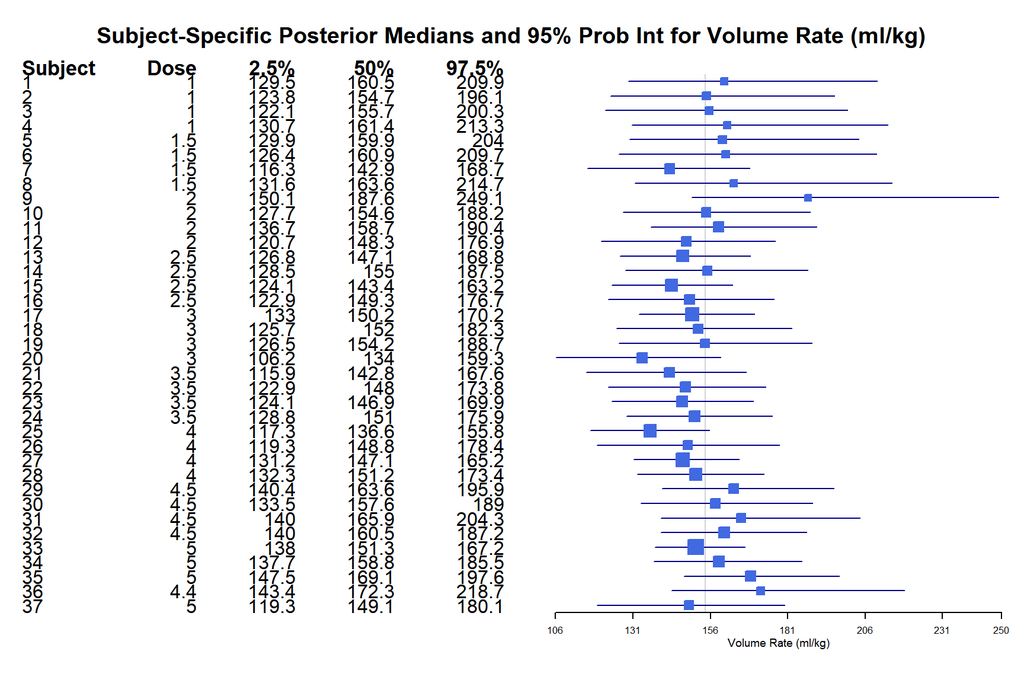

```r
#####   Draw (keep) samples for the subjet-specific parameters from non-linear function

data_subjects_dose = data[,c('indiv', 'dose')]
data_subjects_dose = data_subjects_dose[!duplicated(data_subjects_dose),]

N_subj = length(unique(stan_data$indiv))
par(mfrow=c(1,1))

params = c("median_cl","median_v")
params_labels = c('Clearance Rate (μg/ml/kg)', 'Volume Rate (ml/kg)')

keep <- 1:37#1:stan_data$N_subj#sample(1:N_subj,20)

for (param_ix in 1:length(params)){
  rand_eff_summary = data.frame(summary(argatroban_analytic,
                                        pars=params[param_ix],
                                        probs=c(0.025,0.5,0.975))$summary)

  labelText <- rbind(c("Subject", "Dose", "2.5%", "50%", "97.5%"),
                     round(
                       cbind(data_subjects_dose$indiv[keep],
                             data_subjects_dose$dose[keep],
                             rand_eff_summary$X2.5.[keep],
                             rand_eff_summary$X50.[keep],
                             rand_eff_summary$X97.5.[keep]),1)
  )



  foresplot_data = structure(
                    list(
                       mean = c(NA,rand_eff_summary$X50.[keep]),
                       lower = c(NA,rand_eff_summary$X2.5.[keep]),
                       upper = c(NA,rand_eff_summary$X97.5.[keep])),
                    .Names = c("mean", "lower", "upper"),
                    row.names = c(NA, -38L),
                    class = "data.frame")

  forestplot::forestplot(labelText,
             foresplot_data,
             new_page = TRUE,
             is.summary = c(TRUE, rep(FALSE, 37)),
             #clip=c(100, 250),
             zero=mean(rand_eff_summary$X50.),
             col=fpColors(box="royalblue",
                          lines="darkblue",
                          summary="royalblue"),
            title = paste0("Subject-Specific Posterior Medians and ",
                          "95% Prob Int for ", params_labels[param_ix]),
            xlab = params_labels[param_ix]

  )

}
```

## 7.6 STAN diagnostics

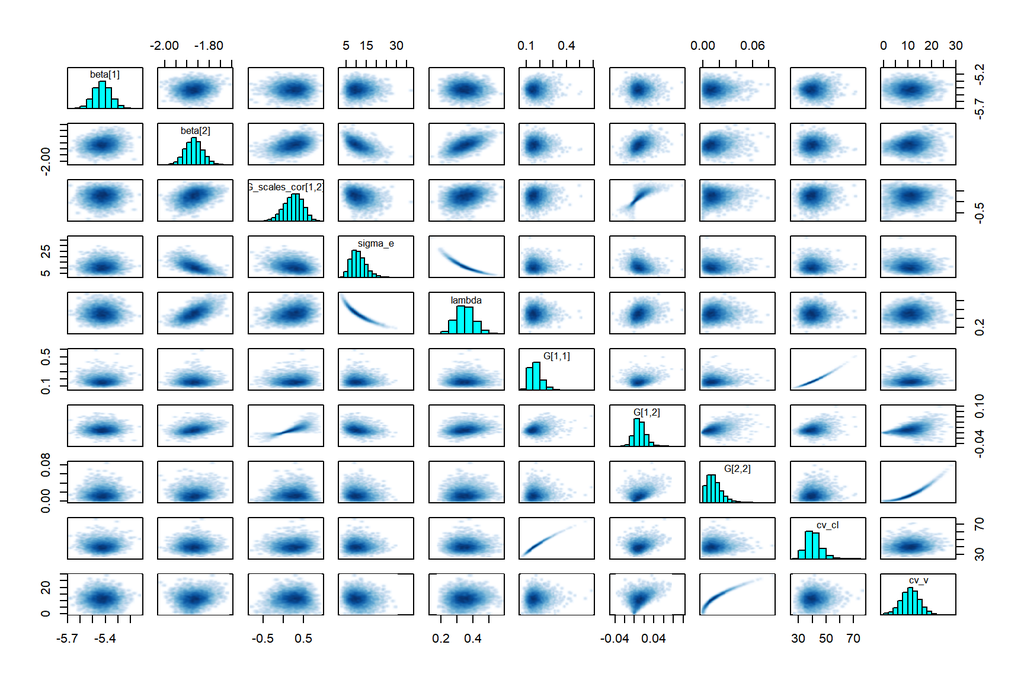

```r
params_main = c("beta[1]", "beta[2]", "sigma_e")
params_main = stan_params
pairs(argatroban_analytic, pars=params_main)
```

# 8 Results and Interpretations

```r
options(knitr.kable.NA = '')

fits_summary %>%
  kbl() %>%
  kable_classic(full_width = F, html_font = "Cambria")%>%
  row_spec(row=0, align = "c", bold=T, extra_css = "border-bottom: 0px solid") %>%
  row_spec(row=1, align = "c", extra_css = "border-bottom: 1px solid") %>%
  row_spec(row=2:11, align = "c")
```

|  |  | R-STAN |  | R-NLME |  | SAS-NLMIXED |  |
| --- | --- | --- | --- | --- | --- | --- | --- |
| Stat | 2.5% | 50% | 97.5% | Estimate | S.E. | Estimate | S.E. |
| beta_1 | -5.56 | -5.425 | -5.289 | -5.43 | 0.062 | -5.424 | 0.063 |
| beta2 | -1.944 | -1.869 | -1.792 | -1.92 | 0.025 | -1.924 | 0.03 |
| Corr | -0.254 | 0.258 | 0.653 | 0.16 |  | 0.19 |  |
| sigma_e | 5.288 | 10.658 | 19.613 | 20.42 |  | 13.88 |  |
| lambda | 0.249 | 0.349 | 0.467 | 0.24 |  |  |  |
| G11 | 0.103 | 0.163 | 0.272 | 0.14 |  | 0.141 |  |
| G12 | -9.673 | 10.269 | 39.126 | 6.73 |  | 6.56 |  |
| G22 | 0.848 | 12.425 | 36.893 | 4.56 |  | 6.01 |  |
| CV Cl | 32.141 | 40.328 | 52.163 | 37.17 |  | 37.54 |  |
| CV V | 2.913 | 11.147 | 19.207 | 6.75 |  | 7.75 |  |

In the previous table, we find the estimates of the coefficients of variation for the subject-specific DE parameters estimates. For the first row, we observe that there was a median of $40.33\%$ variation in the estimate for the clearance rate, $Cl$, of Argatroban in the body $(95%BCI (32.14, 52.16))$. Similarly, the estimated median coefficient of variation for the volume of distribution, $V$, is $11.15\%$ $(95% BCI (2.91,19.21))$. We conclude that the main driver of the heterogeneous response of Argatroban concentration in plasma is the clearance rate. Finally, the estimated median correlation between both clearance and volume rates is $0.26$ $(95\% BCI (-0.25,0.65))$ although this estimate is not significant at the 95% significance level.

# 9 Session Info

```r
library(utils)
```